# Practicals

Michał Bojanowski and Lorien Jasny

Sunbelt-NetSci 2021

# 1 Create small network

Create a directed network shown on the figure below. Mind the labels of the nodes.

```r
g <- igraph::make_graph( ~  A --+ B:C, D --+ E:F, A +--+ D, G +--+ A:D  )
```

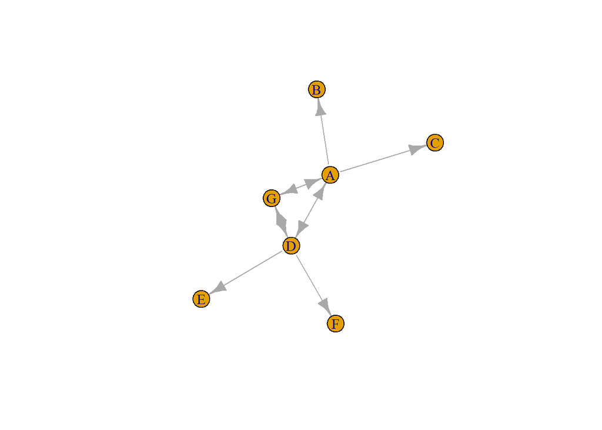

```r
plot(g)
```

# 2 Mutual ties

Transform the network created above to an undirected network such that an undirected tie is present if and only if there are reciprocated ties in the original network. Visualize the network and check the correctness of the result.

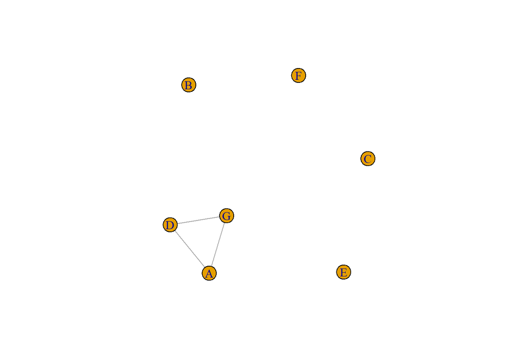

```r
gg <- igraph::as.undirected(g, mode="mutual")
plot(gg)
```

```r
# Verify number of edges
igraph::ecount(gg)
```

```
[1] 3
```

# 3 Histograms of degree distributions

Compute the degree distributions (in-, out- and total) for the classroom network and visualize it with a barchart.

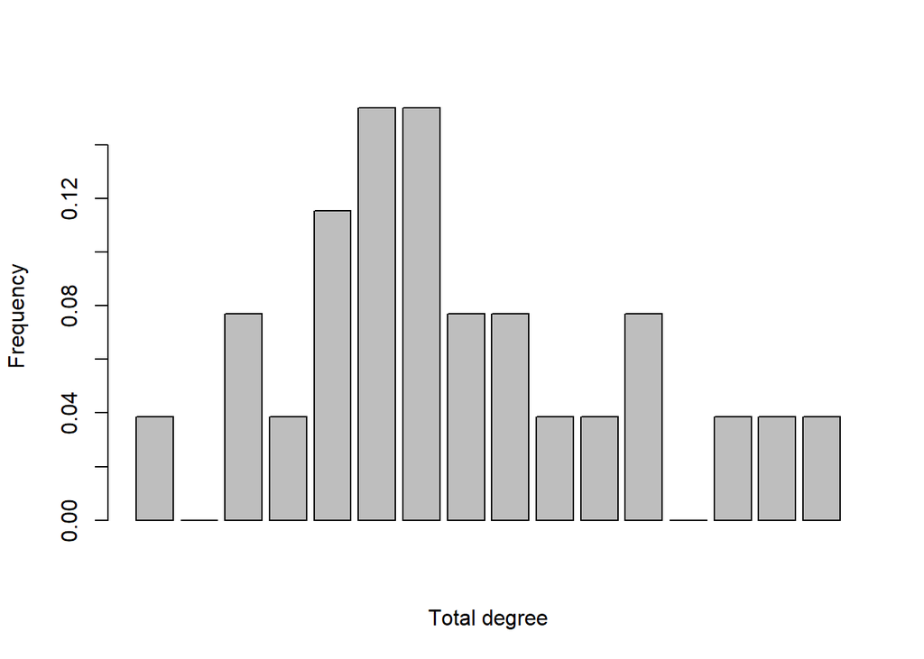

```r
barplot(igraph::degree_distribution(classroom),
        xlab="Total degree", ylab="Frequency")
```

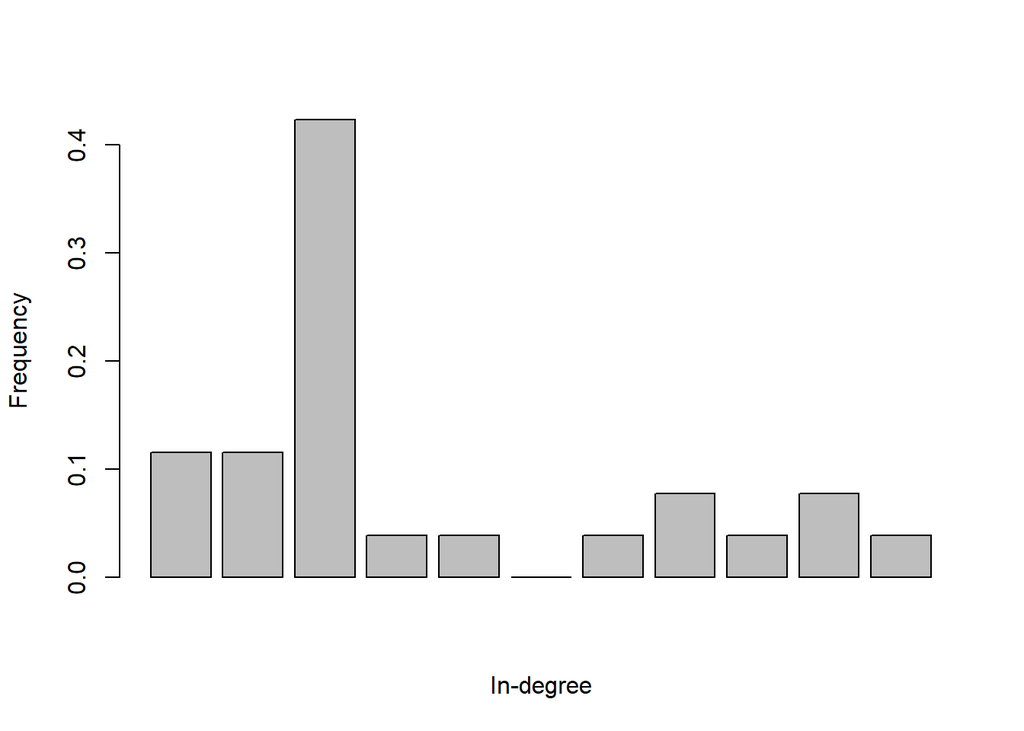

```r
barplot(igraph::degree_distribution(classroom, mode="in"),
        xlab="In-degree", ylab="Frequency")
```

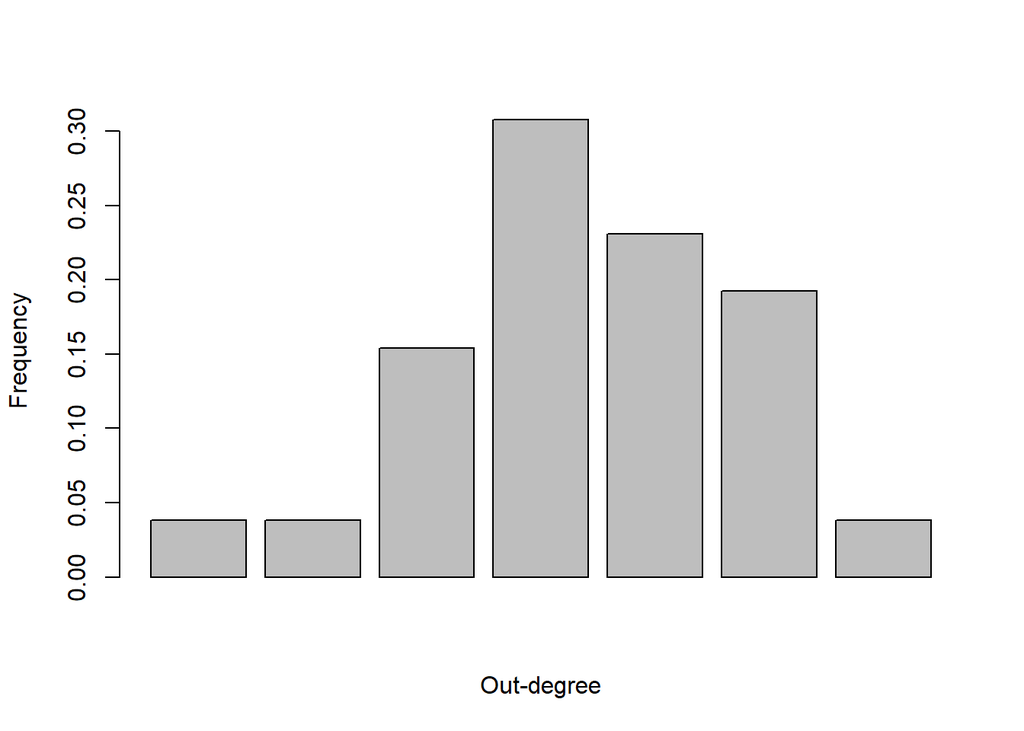

```r
barplot(igraph::degree_distribution(classroom, mode="out"),
        xlab="Out-degree", ylab="Frequency")
```

# 4 Sociality and popularity

Check whether popularity in the classroom is associated with sociality. We will measure popularity with in-degree and sociality with out-degree. Answer the question by

- Creating a scatterplot showing the association between in- and out-degrees.
- Compute the correlation coefficient between the two.

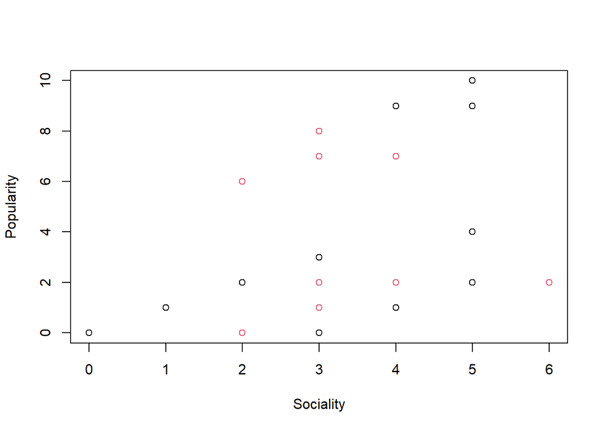

```r
# Data frame with two variables containing in-degrees and out-degrees for each
# vertex
degs <- data.frame(
  indegree=igraph::degree(classroom, mode="in"),
  outdegree = igraph::degree(classroom, mode="out")
)
# Scatterplot
plot(indegree ~ outdegree, data=degs,
     xlab="Sociality", ylab="Popularity",
     col = igraph::V(classroom)$female + 1 )
```

```r
# Correlation coef
cor(degs)
```

```
           indegree outdegree
indegree  1.0000000 0.3498949
outdegree 0.3498949 1.0000000
```